# пупуня

Импортируем необходимые библиотеки

```python
import pandas as pd
import numpy as np
import matplotlib.pyplot as plt
```

Настраиваем отображение графиков прямо в ноутбуке

```python
%matplotlib inline
```

Загружаем датасет Titanic из файла train.csv

```python
df = pd.read_csv('train.csv')
```

Выводим первые 5 строк, чтобы убедиться, что данные загружены корректно

```python
df.head()
```

|  | PassengerId | Survived | Pclass | Name | Sex | Age | SibSp | Parch | Ticket | Fare | Cabin | Embarked |
| --- | --- | --- | --- | --- | --- | --- | --- | --- | --- | --- | --- | --- |
| 0 | 1 | 0 | 3 | Braund, Mr. Owen Harris | male | 22.0 | 1 | 0 | A/5 21171 | 7.2500 | NaN | S |
| 1 | 2 | 1 | 1 | Cumings, Mrs. John Bradley (Florence Briggs Th... | female | 38.0 | 1 | 0 | PC 17599 | 71.2833 | C85 | C |
| 2 | 3 | 1 | 3 | Heikkinen, Miss. Laina | female | 26.0 | 0 | 0 | STON/O2. 3101282 | 7.9250 | NaN | S |
| 3 | 4 | 1 | 1 | Futrelle, Mrs. Jacques Heath (Lily May Peel) | female | 35.0 | 1 | 0 | 113803 | 53.1000 | C123 | S |
| 4 | 5 | 0 | 3 | Allen, Mr. William Henry | male | 35.0 | 0 | 0 | 373450 | 8.0500 | NaN | S |

Задание 2. Знакомство с датасетом

Определяем количество строк и столбцов в датасете

```python
print("Размер датасета (строки, столбцы):", df.shape)
```

```
Размер датасета (строки, столбцы): (891, 12)
```

Выводим названия всех столбцов

```python
print("Названия столбцов:")
print(df.columns.tolist())
```

```
Названия столбцов:
['PassengerId', 'Survived', 'Pclass', 'Name', 'Sex', 'Age', 'SibSp', 'Parch', 'Ticket', 'Fare', 'Cabin', 'Embarked']
```

Смотрим типы данных каждого столбца и количество непустых значений

```python
print("Информация о типах данных:")
df.info()
```

```
Информация о типах данных:
<class 'pandas.core.frame.DataFrame'>
RangeIndex: 891 entries, 0 to 890
Data columns (total 12 columns):
 #   Column       Non-Null Count  Dtype
---  ------       --------------  -----
 0   PassengerId  891 non-null    int64
 1   Survived     891 non-null    int64
 2   Pclass       891 non-null    int64
 3   Name         891 non-null    object
 4   Sex          891 non-null    object
 5   Age          714 non-null    float64
 6   SibSp        891 non-null    int64
 7   Parch        891 non-null    int64
 8   Ticket       891 non-null    object
 9   Fare         891 non-null    float64
 10  Cabin        204 non-null    object
 11  Embarked     889 non-null    object
dtypes: float64(2), int64(5), object(5)
memory usage: 83.7+ KB
```

Задание 3. Анализ пассажиров

Количество пассажиров каждого класса (1, 2, 3)

```python
print("Количество пассажиров по классам:")
print(df['Pclass'].value_counts().sort_index())
```

```
Количество пассажиров по классам:
Pclass
1    216
2    184
3    491
Name: count, dtype: int64
```

Количество мужчин и женщин

```python
print("Количество пассажиров по полу:")
print(df['Sex'].value_counts())
```

```
Количество пассажиров по полу:
Sex
male      577
female    314
Name: count, dtype: int64
```

Разделяем пассажиров на возрастные группы с помощью pd.cut

```python
bins = [0, 12, 17, 35, 60, 100]
labels = ['Ребёнок (0-12)', 'Подросток (13-17)', 'Молодой (18-35)', 'Взрослый (36-60)', 'Пожилой (61+)']
df['AgeGroup'] = pd.cut(df['Age'], bins=bins, labels=labels)
```

Считаем количество пассажиров в каждой возрастной группе

```python
print("Количество пассажиров по возрастным группам:")
print(df['AgeGroup'].value_counts().sort_index())
```

```
Количество пассажиров по возрастным группам:
AgeGroup
Ребёнок (0-12)        69
Подросток (13-17)     44
Молодой (18-35)      384
Взрослый (36-60)     195
Пожилой (61+)         22
Name: count, dtype: int64
```

Средний возраст пассажиров (пропуски автоматически игнорируются)

```python
print("Средний возраст пассажиров:", round(df['Age'].mean(), 2))
```

```
Средний возраст пассажиров: 29.7
```

Медианный возраст пассажиров

```python
print("Медианный возраст пассажиров:", df['Age'].median())
```

```
Медианный возраст пассажиров: 28.0
```

Средняя стоимость билета

```python
print("Средняя стоимость билета:", round(df['Fare'].mean(), 2))
```

```
Средняя стоимость билета: 32.2
```

Задание 4. Сравнение пассажиров разных классов

Сравниваем среднюю стоимость билета для 1, 2 и 3 классов

```python
print("Средняя стоимость билета по классам:")
print(df.groupby('Pclass')['Fare'].mean().round(2))
```

```
Средняя стоимость билета по классам:
Pclass
1    84.15
2    20.66
3    13.68
Name: Fare, dtype: float64
```

Сравниваем средний возраст пассажиров разных классов

```python
print("Средний возраст пассажиров по классам:")
print(df.groupby('Pclass')['Age'].mean().round(2))
```

```
Средний возраст пассажиров по классам:
Pclass
1    38.23
2    29.88
3    25.14
Name: Age, dtype: float64
```

Сравниваем количество мужчин и женщин в каждом классе

```python
print("Количество мужчин и женщин по классам:")
print(df.groupby(['Pclass', 'Sex']).size())
```

```
Количество мужчин и женщин по классам:
Pclass  Sex
1       female     94
        male      122
2       female     76
        male      108
3       female    144
        male      347
dtype: int64
```

Определяем, в каком классе было больше всего пассажиров

```python
print("Самый многочисленный класс:")
print(df['Pclass'].value_counts().idxmax(), "класс —", df['Pclass'].value_counts().max(), "пассажиров")
```

```
Самый многочисленный класс:
3 класс — 491 пассажиров
```

Вывод о различиях между классами:

Пассажиры 1-го класса платили за билет в среднем значительно больше, чем пассажиры 2-го и 3-го классов.

Средний возраст пассажиров 1-го класса выше, чем у 2-го и 3-го.

В 3-м классе больше всего пассажиров, и среди них преобладают мужчины.

Находим самый дорогой билет и выводим информацию о его владельце

```python
max_fare_row = df.loc[df['Fare'].idxmax()]
print("Самый дорогой билет:")
print("Стоимость:", max_fare_row['Fare'])
print("Класс:", max_fare_row['Pclass'])
print("Возраст:", max_fare_row['Age'])
print("Пол:", max_fare_row['Sex'])
print("Выжил:", max_fare_row['Survived'])
```

```
Самый дорогой билет:
Стоимость: 512.3292
Класс: 1
Возраст: 35.0
Пол: female
Выжил: 1
```

Задание 5. Анализ выживаемости

Общее количество выживших и погибших

```python
print("Общее количество выживших и погибших:")
print(df['Survived'].value_counts().rename({0: 'Погиб', 1: 'Выжил'}))
```

```
Общее количество выживших и погибших:
Survived
Погиб    549
Выжил    342
Name: count, dtype: int64
```

Сравниваем выживаемость мужчин и женщин (среднее значение Survived = доля выживших)

```python
print("Доля выживших по полу:")
print(df.groupby('Sex')['Survived'].mean().round(3))
```

```
Доля выживших по полу:
Sex
female    0.742
male      0.189
Name: Survived, dtype: float64
```

Сравниваем выживаемость мужчин и женщин для каждого класса

```python
print("Доля выживших по классу и полу:")
print(df.groupby(['Pclass', 'Sex'])['Survived'].mean().round(3))
```

```
Доля выживших по классу и полу:
Pclass  Sex
1       female    0.968
        male      0.369
2       female    0.921
        male      0.157
3       female    0.500
        male      0.135
Name: Survived, dtype: float64
```

Определяем, какая группа пассажиров имела наибольшую долю выживших

```python
survival_by_group = df.groupby(['Pclass', 'Sex'])['Survived'].mean()
best_group = survival_by_group.idxmax()
best_value = survival_by_group.max()
print(f"Наибольшая доля выживших: класс {best_group[0]}, пол {best_group[1]} — {best_value:.3f}")
```

```
Наибольшая доля выживших: класс 1, пол female — 0.968
```

Задание 6. Визуализация

График количества пассажиров по классам

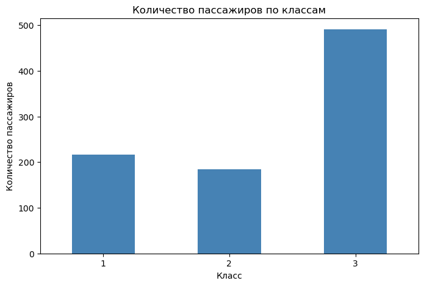

```python
plt.figure(figsize=(8, 5))
df['Pclass'].value_counts().sort_index().plot(kind='bar', color='steelblue')
plt.title('Количество пассажиров по классам')
plt.xlabel('Класс')
plt.ylabel('Количество пассажиров')
plt.xticks(rotation=0)
plt.show()
```

График выживаемости по полу

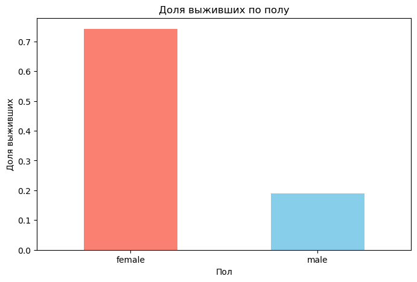

```python
plt.figure(figsize=(8, 5))
df.groupby('Sex')['Survived'].mean().plot(kind='bar', color=['salmon', 'skyblue'])
plt.title('Доля выживших по полу')
plt.xlabel('Пол')
plt.ylabel('Доля выживших')
plt.xticks(rotation=0)
plt.show()
```

Собственный вопрос к данным

Влияет ли порт посадки на долю выживших пассажиров, и сохраняется ли эта закономерность внутри каждого класса?

Смотрим долю выживших в зависимости от порта посадки

```python
print("Доля выживших по порту посадки:")
print(df.groupby('Embarked')['Survived'].mean().round(3))
```

```
Доля выживших по порту посадки:
Embarked
C    0.554
Q    0.390
S    0.337
Name: Survived, dtype: float64
```

Считаем количество пассажиров по каждому порту

```python
print("Количество пассажиров по портам:")
print(df['Embarked'].value_counts())
```

```
Количество пассажиров по портам:
Embarked
S    644
C    168
Q     77
Name: count, dtype: int64
```

Проверяем, сохраняется ли закономерность внутри каждого класса

```python
print("Доля выживших по классу и порту посадки:")
print(df.groupby(['Pclass', 'Embarked'])['Survived'].mean().round(3))
```

```
Доля выживших по классу и порту посадки:
Pclass  Embarked
1       C           0.694
        Q           0.500
        S           0.583
2       C           0.529
        Q           0.667
        S           0.463
3       C           0.379
        Q           0.375
        S           0.190
Name: Survived, dtype: float64
```

Визуализация: доля выживших по порту посадки

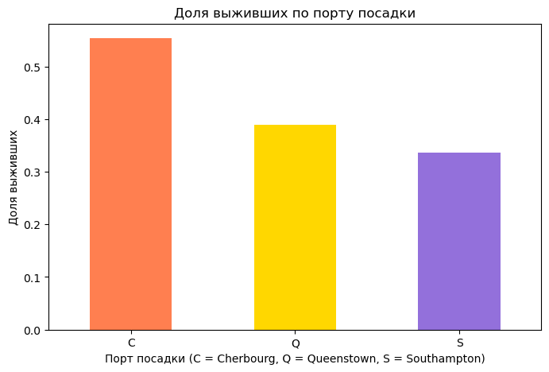

```python
plt.figure(figsize=(8, 5))
df.groupby('Embarked')['Survived'].mean().plot(kind='bar', color=['coral', 'gold', 'mediumpurple'])
plt.title('Доля выживших по порту посадки')
plt.xlabel('Порт посадки (C = Cherbourg, Q = Queenstown, S = Southampton)')
plt.ylabel('Доля выживших')
plt.xticks(rotation=0)
plt.show()
```

Дополнительно: средняя стоимость билета по портам — чтобы понять причину различий

```python
print("Средняя стоимость билета по портам:")
print(df.groupby('Embarked')['Fare'].mean().round(2))
```

```
Средняя стоимость билета по портам:
Embarked
C    59.95
Q    13.28
S    27.08
Name: Fare, dtype: float64
```

И распределение классов по портам

```python
print("Распределение классов по портам (количество пассажиров):")
print(pd.crosstab(df['Embarked'], df['Pclass']))
```

```
Распределение классов по портам (количество пассажиров):
Pclass      1    2    3
Embarked
C          85   17   66
Q           2    3   72
S         127  164  353
```